# PLANEJAMENTO DE EXPERIMENTOS A (MATD48)

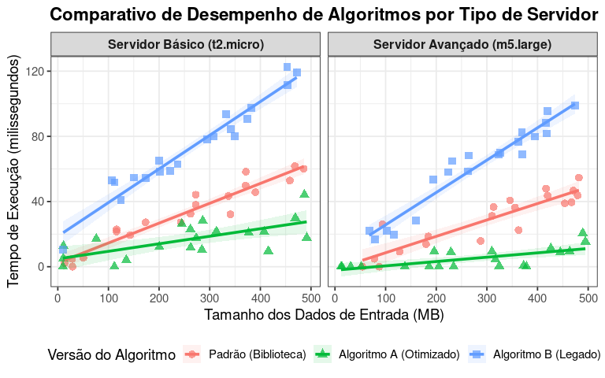

- **Professor:** Raydonal Ospina Martínez
- **Homepage do Curso:** https://raydonal.github.io/matd48/
- **Contato:** raydonalmartinez@ufba.br
- **Ementa do curso:** Princípios fundamentais de planejamentos experimentais e os delineamentos básicoa e suas análises. O problema de parcelas perdidas. Análise de covariância. Introdução aos planos fatoriais, efeitos principais e interações. Análise de variância de delineamentos fatoriais simples.
- **Local e horário da disciplina:** 2025.2 Local: PAF 1 ((PAF - Pavilhão de Aulas da Federação I - Av. Barão de Geremoabo - s/n - Ondina - Campus de Ondina).) - Sala 208 - Terça Horários 10:40 às 12:30; Lab 140 - IME - Quinta Horários 10:40 às 12:30.
- **Atenção aos estudantes:** Reunião virtual via google-meet ou reunião presencial com prévio agendamento. O local de atendimento presencial será em alguma sala disponível no Departamento de Estatística da UFBA.
- *Nota: O atendimento somente será realizado com agendamento prévio. Caro aluno, eu sou uma pessoa bastante ocupada e meu tempo, assim como o seu, é muito valioso. Use o tempo que você gastar comigo de forma eficiente. De preferência já traga anotações e perguntas já elaboradas. Seja pontual. Sempre.*
- **Inicio do curso:** 09 de setembro de 2025.
- **Pré-requisitos:** ( ( MATD41A ou MATD41 ) e ( MATD43A ou MATD43 ) ) . A disciplina também requer conhecimentos sólidos de algebra e probabilidade.
- **Propósitos da disciplina:** Capacitar o aluno a planejar, conduzir e analisar experimentos de forma estatisticamente rigorosa, permitindo a obtenção de conclusões válidas sobre relações de causa e efeito. A disciplina busca desenvolver o pensamento crítico para controlar fontes de variabilidade, maximizar a precisão das estimativas e garantir a validade interna e externa dos resultados. Prepara o futuro estatístico para atuar em áreas como pesquisa científica, desenvolvimento de produtos, otimização de processos, ensaios clínicos e testes A/B.
- **Objetivos da disciplina:**Diferenciar estudos observacionais de experimentais e dominar os princípios fundamentais da experimentação (repetição, casualização e controle local). Identificar e aplicar os principais delineamentos experimentais: Inteiramente Casualizado (DIC), Blocos Completos Casualizados (DBC) e Quadrado Latino (DQL). Construir o modelo estatístico adequado para cada delineamento e realizar a Análise de Variância (ANOVA) para testar as hipóteses de interesse. Verificar os pressupostos de validade do modelo através da análise de resíduos. Executar e interpretar testes de comparações múltiplas para identificar diferenças entre tratamentos. Analisar experimentos fatoriais, interpretando corretamente os efeitos principais e as interações.

A avaliação tem como objetivo ajudar ao aluno a progredir nas suas aprendizagens e serve também para estabelecer os resultado dos conhecimentos e das competências adquiridas nos diferentes momentos do período acadêmico. A avaliação também contribui para a qualidade do sistema de ensino. Desta forma, os critérios de avaliação para este curso são:

[output not shown]

A avaliação será constituída pela nota das atividades (que podem consistir em provas, Desafios, listas de exercicios e/ou projetos a depender do desempenho e participação da turma). O grau atribuído ao aluno no final do curso será o da sua média global ponderada (média aritmética ponderada) entre as notas, i.e.,

### M = (0,5 * A1)+(0,5 * A2)

- **Nota:** Não haverá escalonamento de notas.

# Programa da disciplina (Tentativo)

| Data de Início | Data de Fim | Tópico / Atividade Programada |
| --- | --- | --- |
| 02/09/2025 | 02/09/2025 | Congresso UFBA (Não haverá aula) |
| 04/09/2025 | 04/09/2025 | Congresso UFBA (Não haverá aula) |
| 09/09/2025 | 09/09/2025 | Princípios da experimentação [Mat-01]. |
| 11/09/2025 | 11/09/2025 | Fatores, níveis e tratamentos. Erro experimental. [Mat-02] |
| 16/09/2025 | 16/09/2025 | Modelos de ANOVA. |
| 18/09/2025 | 18/09/2025 | Unidades experimentais. Caracterização e escolha das unidades. [Mat-03] |
| 23/09/2025 | 23/09/2025 | Técnicas para aumentar a precisão. |
| 25/09/2025 | 25/09/2025 | Experimentos Inteiramente Casualizados (DIC). |
| 30/09/2025 | 30/09/2025 | Modelo matemático para o DIC. [Mat-04] |
| 02/10/2025 | 02/10/2025 | Análise de Variância (ANOVA) para o DIC. **Aula prática em R** |
| 07/10/2025 | 07/10/2025 | Teste F para médias de tratamentos. [Mat-05] |
| 09/10/2025 | 09/10/2025 | Coeficiente de variação. Análise de pressupostos. |
| 14/10/2025 | 14/10/2025 | Análise de Covariância (ANCOVA). |
| 16/10/2025 | 16/10/2025 | Aula de exercícios e **Aula prática em R** [Mat-06] |
| 21/10/2025 | 21/10/2025 | ANCOVA e revisão. |
| 23/10/2025 | 23/10/2025 | Comparações de médias. Contrastes |
| 28/10/2025 | 28/10/2025 | Contrastes ortogonais. **Aula prática em R** [Mat-07] |
| **30/10/2025** | **30/10/2025** | **PROVA 1** |
| 04/11/2025 | 04/11/2025 | Procedimentos de Tukey e Scheffé. |
| 06/11/2025 | 06/11/2025 | Procedimentos de Bonferroni e Duncan. **Aula prática em R** |
| 11/11/2025 | 11/11/2025 | Aula de exercícios sobre Comparações Múltiplas. [Mat-08] |
| 13/11/2025 | 13/11/2025 | Experimentos em Blocos Completos Casualizados (DBC). |
| 18/11/2025 | 18/11/2025 | Modelo matemático e ANOVA para DBC. **Aula prática em R** |
| 20/11/2025 | 20/11/2025 | Eficiência do delineamento. [Mat-09] |
| 25/11/2025 | 25/11/2025 | Experimentos em Quadrados Latinos (DQL). [Mat-10] |
| 27/11/2025 | 27/11/2025 | Modelo matemático e ANOVA para DQL. **Aula prática em R** |
| 02/12/2025 | 04/12/2025 | Réplicas em DQL |
| 11/12/2025 | 11/12/2025 | Quadrados Greco-latinos [Mat-11] |
| 16/12/2025 | 16/12/2025 | Experimentos Fatoriais: Introdução. |
| 18/12/2025 | 18/12/2025 | Fatores aninhados e cruzados. Modelo matemático. |
| 23/12/2025 | 23/12/2025 | Cálculo dos efeitos principais e interações. **Aula prática em R** |
| 25/12/2025 | 25/12/2025 | Delineamentos para experimentos fatoriais. |
| 30/12/2025 | 30/12/2025 | ANOVA para experimentos fatoriais. [Mat-12] |
| **05/01/2026** | **05/01/2026** | **PROVA 2** |

#### Dados

- [Restaurantes]
- [Gasto]
- [Peso]
- [GDP]
- [EITC]
- [EITC]

#### Referências bibliográficas (Principal)

1. Montgomery, D. C. (2017). **Design and analysis of experiments**. John Wiley & Sons. **(Livro principal)**
2. Box, G. E., Hunter, J. S., & Hunter, W. G. (2005). **Statistics for experimenters: design, innovation, and discovery**. Wiley-Interscience.
3. Kuehl, R. O. (2000). **Design of experiments: statistical principles of research design and analysis**. Cengage Learning.
4. Ribeiro, J. L. D. (2018). **Análise de Variância e Regressão**. Editora Appris. (Em português)

#### Referências bibliográficas

- Casella, G. (2008). *Statistical design.* Springer.
- Cox, D. R., & Reid, N. (2000). *The theory of the design of experiments.* CRC press.
- Hinkelmann, K., & Kempthorne, O. (2008). *Design and analysis of experiments, volume 1: Introduction to experimental design*. John Wiley & Sons.

#### Software (Interessados em implementar seus conhecimentos)

1. [An Introduction to R](http://cran.r-project.org)
2. [SAS - Acadêmico](https://www.sas.com/pt_br/learn/academic-programs/software.html)
3. Rstudio
4. TeXnicCenter
5. [Python](http://www.python.org/)
6. [Julia](https://julialang.org/)

## Para refletir

##### Sobrea as aulas

*São reuniões cientificas e profissionais onde são discutidos temas de relevância para a formação pessoal, social e profissional. Portanto é esperado que o aluno chegue sem atraso, não entre na sala abruptamente, não sai da sala durante a discussão, respeite as intervenções do professor e/ou colega(s), não fume (Lei Federal), não use o celular (caso precisar pode se retirar da sala) e não promova a destruição de bens públicos, entre outros.*

##### Sobre honestidade acadêmica

*Honestidade e confiança são importantes para todos nós como indivíduos. Neste sentido, os membros da comunidade acadêmica tanto como professores e alunos têm a responsabilidade de manter e promover os princípios da verdade e honestidade acadêmica. Assim, a honestidade acadêmica pressupõe que todos os trabalhos, provas e testes sejam frutos do trabalho individual do aluno salvo os casos onde o professor tenha dado permissão expressa e instruções para a realização de atividades em grupo.*

##### Sobre profissionalismo

*Aluno, você já não é mais criança ou adolescente, mas adulto. Durante seu tempo na universidade, você formará quem você será pelas próximas décadas. O mercado de trabalho quer apenas os melhores e os mais profissionais. Haja desde já como o profissional que você deseja ser. (Fonte: Política do Curso e Etiqueta em Sala de Aula, Professor Dr. Renato J. Cintra).*

##### Sobre tratamento pessoal

*Lembrem que nós somos respeitados e tratados da mesma forma em que tratamos as demais pessoas. Ao se dirigir a professores e/ou colegas, faça-o respeitosamente.*

##### Sobre o aluno

*Finalmente quero lembrá-lo que você constrói seu conhecimento e desenvolve sua capacidade de aprender e criar. Seu instrutor está aqui para orientá-lo. Trabalhe, pesquise, seja crítico construtivo, crie, se dedique, se esforce e não desista, se pensar em desistir se esforce mais. Não se preocupe e melhor se ocupe. Você está aqui porque tem condições de vencer.*

### Material de apoio

O material de apoio será distribuído ao longo do curso. Esse material pode incluir, livros, slides de aula, scripts para reprodução, artigos científicos, artigos dedivulgação, entre outros.

### Provas

- [ Prova I ]

###### Content Copyright © 2025 Raydonal Ospina Martínez. All Rights Reserved.